# CIs Homework

# Task 1.

Load the data again, clean_names(), and re-familiarise yourself with it

```r
# load in libraries and data
library(tidyverse)
library(janitor)
library(infer)

ames <- read_csv(here::here("data/ames.csv")) %>%
  clean_names()
```

# Task 2.

Investigate the distribution of lot_area. Is the distribution roughly normal? If not, what problems do you find? **Answer:** The data is very compressed at the lower end of the scale. It is difficult to assertain the distribution as it only spans a few columns.

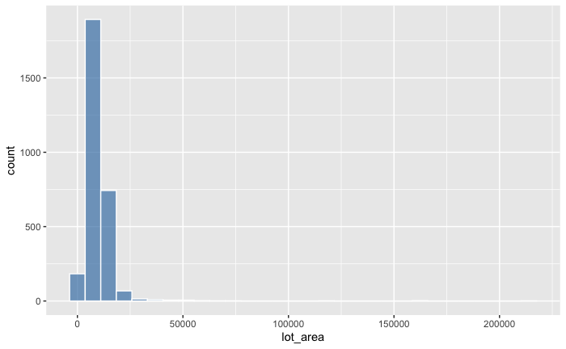

```r
ames %>%
  ggplot(aes(x = lot_area)) +
  geom_histogram(col = "white", fill = "steel blue", alpha = 0.7)
```

# Task 3.

Compute and visualise a bootstrap sampling distribution for the mean(lot_area) of the sold houses.

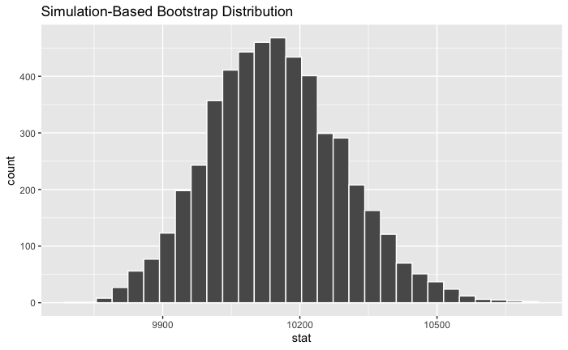

# Task 4.

Use your bootstrap distribution to calculate a 95% CI for mean(lot_area), and visualise it on the distribution

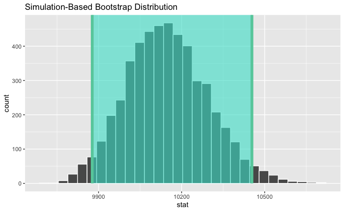

# Task 5.

You would like to know the mean(lot_area) of the sold houses with higher confidence. Calculate the 99% CI for this variable (you can re-use your bootstrap distribution from above). Is it narrower or broader than the 95% CI? Does that make sense?

**Answer:** The 99% ci is a little wider than the 95% ci which is as I would expect.

| lower_ci | upper_ci |
| --- | --- |
| 9877.140 | 10453.98 |
| 9805.934 | 10558.73 |

# Task 6.

Calculate the point estimate of the mean(lot_area) **Answer:** The point estimate is 10147.96

```r
# calculating the point estimate
mean_infer <- infer_ames_resample %>%
  summarise(mean = mean(stat))

mean_infer
```

| mean |
| --- |
| 10147.96 |